# autoplots

autoplot.basis Autoplot spline basis instances

#### Description

Autoplot spline basis instances

#### Usage

```
## S3 method for class 'basis'
autoplot(object, data, n = 256, ...)
```

#### Arguments

- `object`: spline basis object
- `data`: x-values at which to evaluate the splines. Optional. By default, an evenly spaced sequence of 256 values covering the range of the splines will be used.
- `n`: If data is not provided, instead use an evenly-spaced sequence of x-values of this length (plus one, since both endpoints are included). If data is provided, this argument is ignored.
- `...`: Ignored.

Value ggplot

#### Examples

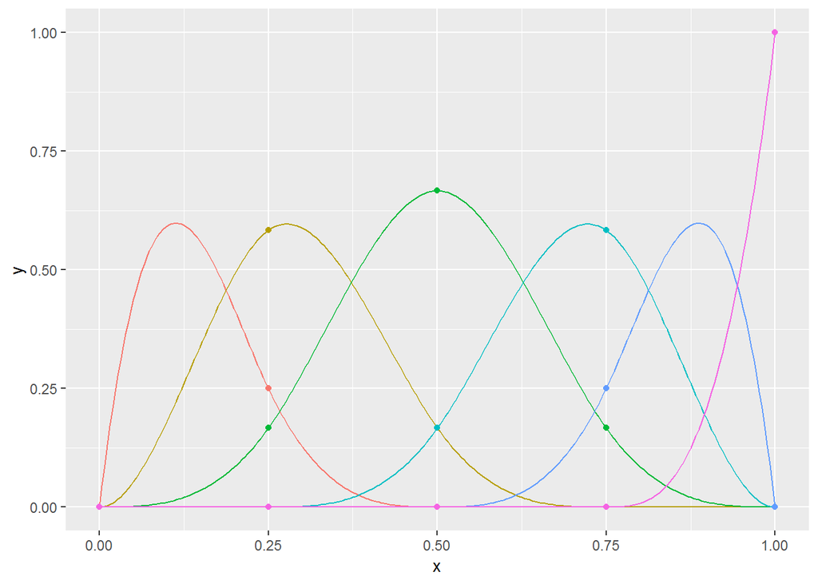

```r
library(splines)
x <- seq(0, 1, by=0.001)
spl <- bs(x, df=6)
autoplot(spl)
```

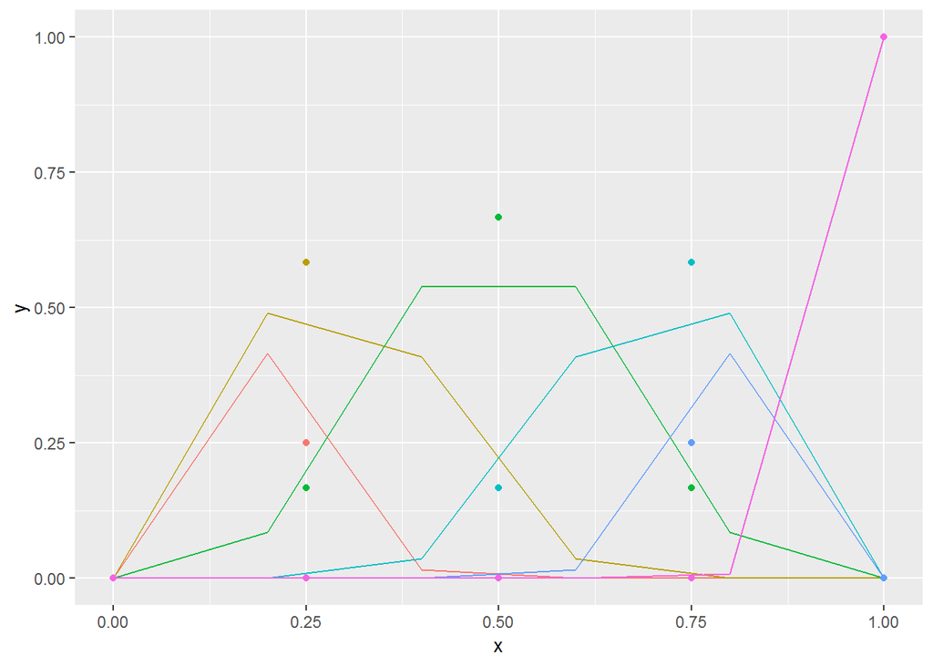

```r
autoplot(spl, n=5)
```

autoplot.breakpoints Autoplot strucchange::breakpoints

#### Description

Autoplot strucchange::breakpoints

#### Usage

```
## S3 method for class 'breakpoints'
autoplot(object, data = NULL, cpt.colour = "#FF0000",
cpt.linetype = "dashed", ...)
```

#### Arguments

- `object`: strucchange::breakpoints or strucchange::breakpointsfull instance.
- `data`: Original time series. Mandatory for plotting strucchange::breakpoints instance.
- `cpt.colour`: Line colour for changepoints
- `cpt.linetype`: Line type for changepoints
- `...`: other arguments passed to autoplot.ts

Value ggplot

#### Examples

```r
library(strucchange)
```

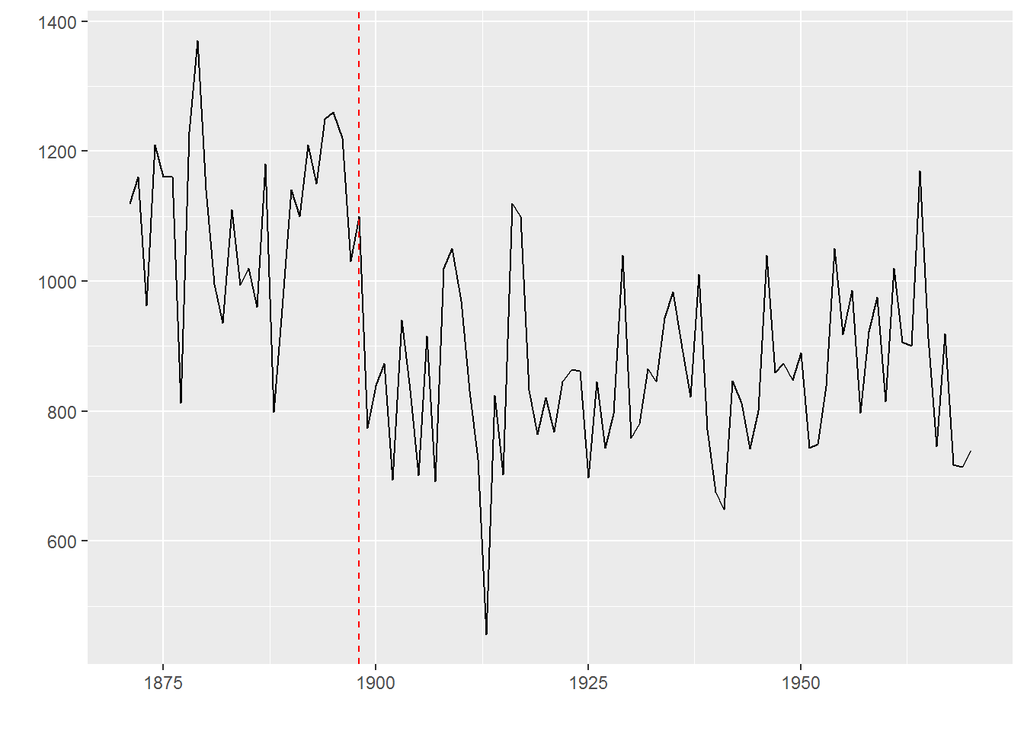

```r
bp.nile <- breakpoints(Nile ~ 1)
autoplot(bp.nile)
```

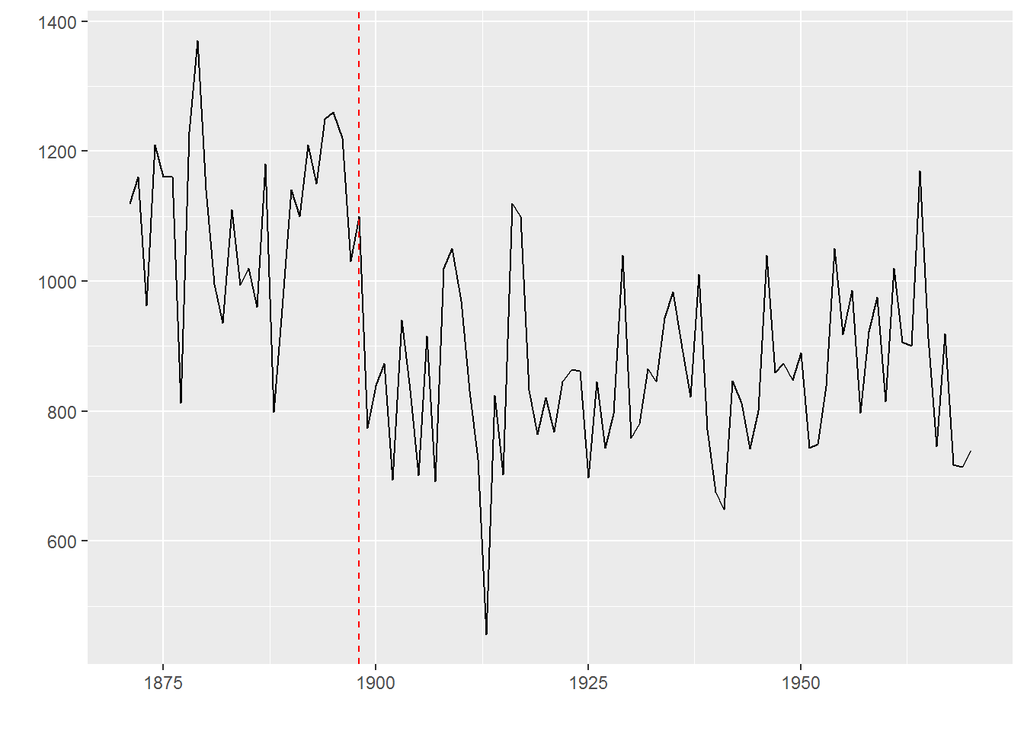

```r
autoplot(bp.nile, is.date = TRUE)
```

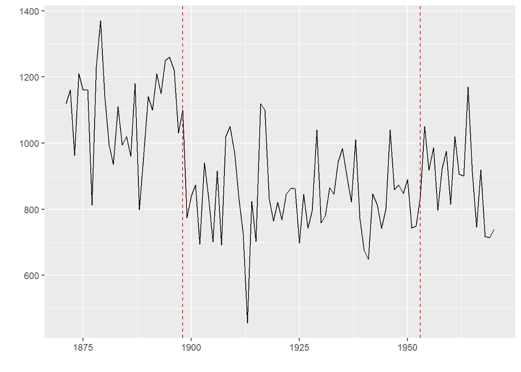

```r
autoplot(breakpoints(bp.nile, breaks = 2), data = Nile)
```

autoplot.cpt Autoplot changepoint::cpt

#### Description

Autoplot changepoint::cpt

#### Usage

```
## S3 method for class 'cpt'
autoplot(object, is.date = NULL, cpt.colour = "#FF0000",
cpt.linetype = "dashed", ...)
```

#### Arguments

- `object`: changepoint::cpt instance
- `is.date`: Logical frag indicates whether the stats::ts is date or not. If not provided, regard the input as date when the frequency is 4 or 12.
- `cpt.colour`: Line colour for changepoints
- `cpt.linetype`: Line type for changepoints
- `...`: other arguments passed autoplot.ts

Value ggplot

#### Examples

```r
library(changepoint)
```

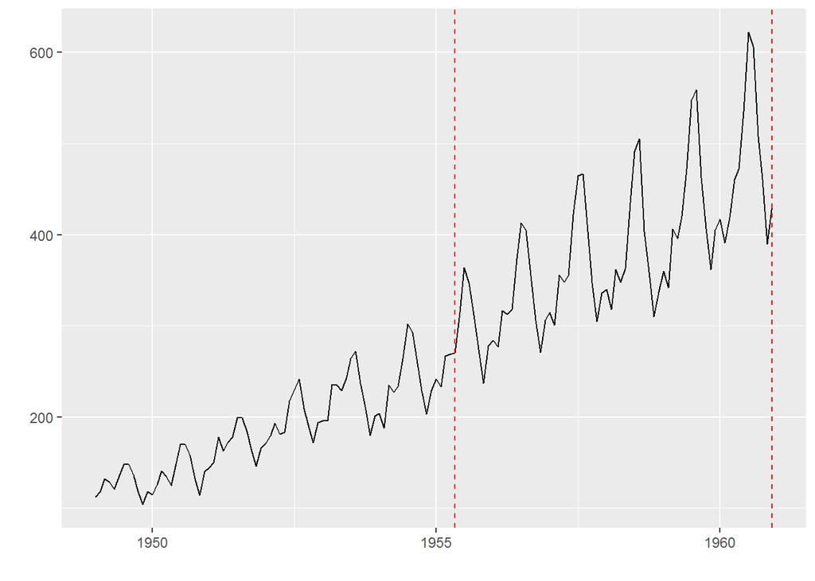

```r
autoplot(cpt.mean(AirPassengers))
```

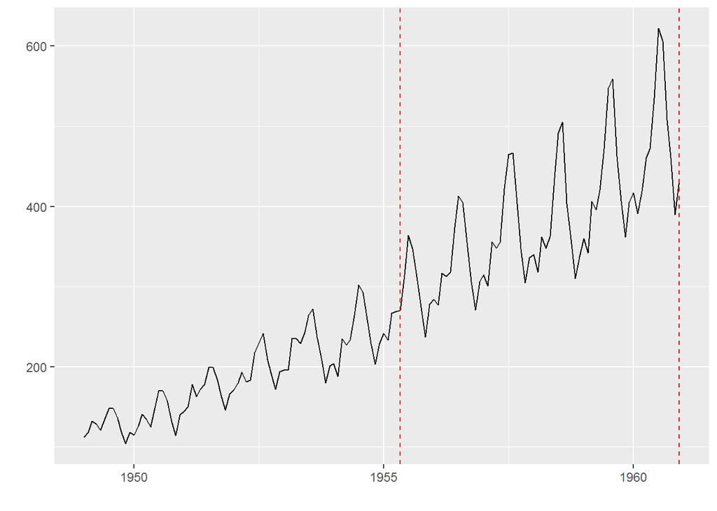

```r
autoplot(cpt.meanvar(AirPassengers))
```

autoplot.cv.glmnet

Autoplot glmnet::cv.glmnet

#### Description

Autoplot glmnet::cv.glmnet

#### Usage

```
## S3 method for class 'cv.glmnet'
autoplot(object, sign.lambda = 1, label.n = 12, label = TRUE, label.label = "nz", label.colour = NULL,
label.alpha = NULL, label.size = NULL, label.angle = NULL, label.family = NULL, label.fontface = NULL, label.lineheight = NULL, label.hjust = NULL, label.vjust = NULL, label.repel = FALSE,
xlim = c(NA, NA), ylim = c(NA, NA), log = "", main = NULL, xlab = NULL, ylab = NULL, asp = NULL, ...)
```

#### Arguments

- `object`: glmnet::cv.glmnet instance
- `sign.lambda`: Either plot against log(lambda) (default) or its negative if sign.lambda=-1.
- `label.n`: Number of Df labels
- `label`: Logical value whether to display labels
- `label.label`: Column name used for label text
- `label.colour`: Colour for text labels
- `label.alpha`: Alpha for text labels
- `label.size`: Size for text labels
- `label.angle`: Angle for text labels
- `label.family`: Font family for text labels
- `label.fontface`: Fontface for text labels
- `label.lineheight`: Lineheight for text labels
- `label.hjust`: Horizontal adjustment for text labels
- `label.vjust`: Vertical adjustment for text labels
- `label.repel`: Logical flag indicating whether to use ggrepel, enabling this may take some time for plotting
- `xlim`: limits for x axis
- `ylim`: limits for y axis
- `log`: which variables to log transform (“x”, “y”, or “xy”) main character vector or expression for plot title
- `xlab`: character vector or expression for x axis label
- `ylab`: character vector or expression for y axis label
- `asp`: the y/x aspect ratio
- `...`: other arguments passed to methods

Value ggplot

#### Examples

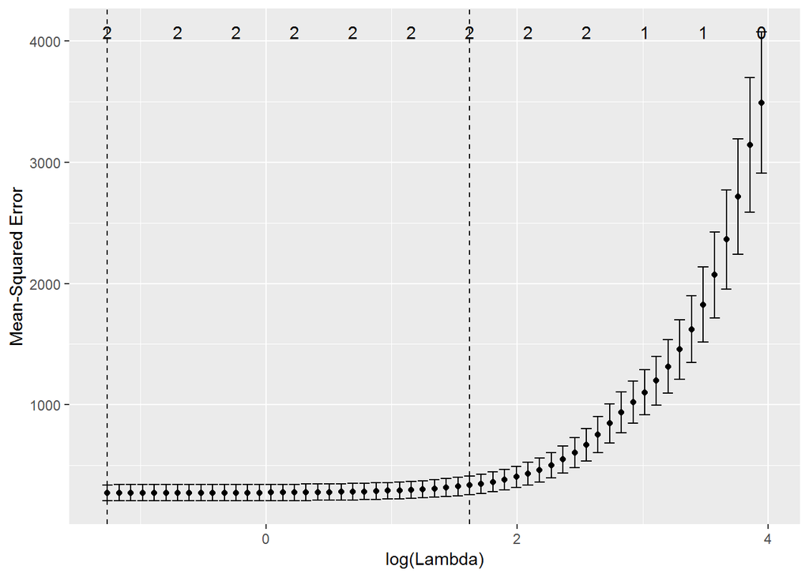

```r
autoplot(glmnet::cv.glmnet(data.matrix(Orange[-3]), data.matrix(Orange[3])))
```